# Atividade 2 - Análise Exploratória com Python/Pandas

##### !!!Nome de colunas modificadas no exercício anterior pelo Power Query, além de algumas colunas desnecessárias!!!

Objetivo pessoal: gerar gráficos semelhantes aos gráficos realizados na primeira atividade, buscando aprofundar os conhecimentos em Python e suas bibliotecas. Dessa forma, consigo utilizar conhecimentos prévios atribúidos às análises a fim de absorver conhecimentos novos com mais facilidade. Além de poder comparar se as análises estão corretas.

#### Importando bibliotecas:

```python
#Importação de dados, tratamento, análise
import pandas as pd
#Funções e comandos para exibição de gráficos
import matplotlib.pyplot as plt
#Funções e comandos para exibição de gráficos
import seaborn as sns
#Funções e comandos para trabalhar com números (formatação, cálculos)
import numpy as np
#Detalhes sobre os avisos e alertas
import plotly.express as px
```

Lendo o arquivo com os dados dos pedidos da indústria textil, além de testar se está tudo nos conformes:

```python
df = pd.read_excel("PEDIDOS_INDUSTRIA_TEXTIL_V1.xlsx")
```

```python
#Comando para saber quantas linhas e colunas possui o arquivo
df.shape
```

```
(7358, 48)
```

```python
#Comando para exibir todas as colunas do arquivo
pd.set_option("display.max_columns", None)
pd.set_option('display.max_rows', None)

#Teste linhas iniciais do Dataframe
df.head()
```

|  | id | pedido | data_venda | data_hora_emissao_pedido | data_hora_fechamento_pedido | data_fatura_pedido | bloqueio_pedido | desbloqueio_pedido | status_desbloqueio | reserva_pedido | emissao_fatura | expedicao_fatura | previsao_atendimento_pedido | regiao | coordenacao | coordenacao_venda | representante | representada | cnpf | codigo_grupo_fin | dsc_grupo_fin | cliente | estado | segmento | categoria_final | codigo_artigo | codigo_familia | codigo_caracteristica | cod_comparacao | … |
| --- | --- | --- | --- | --- | --- | --- | --- | --- | --- | --- | --- | --- | --- | --- | --- | --- | --- | --- | --- | --- | --- | --- | --- | --- | --- | --- | --- | --- | --- | --- |
| 0 | 2517441 | 251744 | 2010-05-01 | 2010-04-01 00:30:31 | 2010-04-01 12:07:10 | 2010-05-20 | 2010-04-01 12:07:10 | 2010-04-14 12:48:22 | Outros | 2010-05-11 12:00:00 | 2010-05-12 | 2010-05-13 | 2010-05-30 | SSC | Santa Catarina / Rio G do Sul | Gerência (Norte e Sul) | 1712 | RPLS REPRESENTACOES LTDA | 7921909000121 | 15000282 | MAND CONFECS RAFREE | RAFER IND E COM DE CONFEC LTDA EP | SC | COLOURS | CONFECCIONISTAS MODA | 1616 | 30 | 9 | 3009 | … |
| 1 | 2517481 | 251748 | 2010-05-01 | 2010-04-01 00:30:31 | 2010-04-01 12:07:14 | 2010-05-20 | NaT | NaT | NaN | 2010-05-11 12:00:00 | 2010-05-12 | 2010-05-13 | 2010-05-30 | SSC | Santa Catarina / Rio G do Sul | Gerência (Norte e Sul) | 1712 | RPLS REPRESENTACOES LTDA | 73439374000181 | 0 | SEM GRUPO FINANCEIRO | CONFEC THAROG LTDA | SC | COLOURS | CONFECCIONISTAS MODA | 1616 | 30 | 9 | 3009 | … |
| 2 | 3810051 | 381005 | 2010-05-01 | 2010-04-01 09:36:46 | 2010-04-01 12:08:44 | 2010-05-25 | 2010-04-15 15:40:24 | 2010-04-22 18:18:07 | Outros | 2010-04-27 18:37:22 | 2010-05-22 | 2010-05-23 | 2010-05-30 | SP3 | São Paulo 3 | Gerência (Norte e Sul) | 3334 | JOSE LUIZ PIRES REPRES S/C LTD | 4653558000127 | 0 | SEM GRUPO FINANCEIRO | ETNIA CONFEC E COM DE ROUPAS LTDA ME | SP | COLOURS | CONFECCIONISTAS MODA | 1616 | 30 | 1 | 3001 | … |
| 3 | 3810051 | 381005 | 2010-05-01 | 2010-04-01 09:36:46 | 2010-04-01 12:08:44 | 2010-05-25 | 2010-04-15 15:40:24 | 2010-04-22 18:18:07 | Outros | 2010-05-03 09:30:50 | 2010-05-22 | 2010-05-23 | 2010-05-30 | SP3 | São Paulo 3 | Gerência (Norte e Sul) | 3334 | JOSE LUIZ PIRES REPRES S/C LTD | 4653558000127 | 0 | SEM GRUPO FINANCEIRO | ETNIA CONFEC E COM DE ROUPAS LTDA ME | SP | COLOURS | CONFECCIONISTAS MODA | 1616 | 30 | 1 | 3001 | … |
| 4 | 3810051 | 381005 | 2010-05-01 | 2010-04-01 09:36:46 | 2010-04-01 12:08:44 | 2010-05-25 | 2010-04-15 15:40:24 | 2010-04-22 18:18:07 | Outros | 2010-05-14 12:11:25 | 2010-05-22 | 2010-05-23 | 2010-05-30 | SP3 | São Paulo 3 | Gerência (Norte e Sul) | 3334 | JOSE LUIZ PIRES REPRES S/C LTD | 4653558000127 | 0 | SEM GRUPO FINANCEIRO | ETNIA CONFEC E COM DE ROUPAS LTDA ME | SP | COLOURS | CONFECCIONISTAS MODA | 1616 | 30 | 1 | 3001 | … |

```python
#Teste linhas finais do Dataframe
df.tail()
```

|  | id | pedido | data_venda | data_hora_emissao_pedido | data_hora_fechamento_pedido | data_fatura_pedido | bloqueio_pedido | desbloqueio_pedido | status_desbloqueio | reserva_pedido | emissao_fatura | expedicao_fatura | previsao_atendimento_pedido | regiao | coordenacao | coordenacao_venda | representante | representada | cnpf | codigo_grupo_fin | dsc_grupo_fin | cliente | estado | segmento | categoria_final | codigo_artigo | codigo_familia | codigo_caracteristica | cod_comparacao | … |
| --- | --- | --- | --- | --- | --- | --- | --- | --- | --- | --- | --- | --- | --- | --- | --- | --- | --- | --- | --- | --- | --- | --- | --- | --- | --- | --- | --- | --- | --- | --- |
| 7353 | 46276510 | 462765 | 2010-06-01 | 2010-06-24 16:52:21 | 2010-06-24 17:13:19 | NaT | NaT | NaT | NaN | 2010-06-25 10:20:03 | 2010-06-26 | 2010-06-27 | 2010-07-24 | SBA | Espírito Santo | Gerência (Norte e Sul) | 2920 | JAIR GOMES LIMA- ME | 9344716000180 | 15001907 | MAND ESTORILLITORANIA | PEQUIM TEXTIL LTDA | ES | COLOURS | Atacado Plus | 58164 | 30 | 1 | 3001 | … |
| 7354 | 46276511 | 462765 | 2010-06-01 | 2010-06-24 16:52:21 | 2010-06-24 17:13:19 | NaT | NaT | NaT | NaN | 2010-06-25 10:20:03 | 2010-06-26 | 2010-06-27 | 2010-07-24 | SBA | Espírito Santo | Gerência (Norte e Sul) | 2920 | JAIR GOMES LIMA- ME | 9344716000180 | 15001907 | MAND ESTORILLITORANIA | PEQUIM TEXTIL LTDA | ES | COLOURS | Atacado Plus | 58164 | 30 | 1 | 3001 | … |
| 7355 | 46276512 | 462765 | 2010-06-01 | 2010-06-24 16:52:21 | 2010-06-24 17:13:19 | NaT | NaT | NaT | NaN | 2010-06-25 10:20:03 | 2010-06-26 | 2010-06-27 | 2010-07-24 | SBA | Espírito Santo | Gerência (Norte e Sul) | 2920 | JAIR GOMES LIMA- ME | 9344716000180 | 15001907 | MAND ESTORILLITORANIA | PEQUIM TEXTIL LTDA | ES | COLOURS | Atacado Plus | 68616 | 30 | 2 | 3002 | … |
| 7356 | 46276522 | 462765 | 2010-06-01 | 2010-06-24 16:52:21 | 2010-06-24 17:13:19 | NaT | NaT | NaT | NaN | 2010-06-25 10:20:03 | 2010-06-26 | 2010-06-27 | 2010-07-24 | SBA | Espírito Santo | Gerência (Norte e Sul) | 2920 | JAIR GOMES LIMA- ME | 9344716000180 | 15001907 | MAND ESTORILLITORANIA | PEQUIM TEXTIL LTDA | ES | COLOURS | Atacado Plus | 11315 | 48 | 1 | 4801 | … |
| 7357 | 46276523 | 462765 | 2010-06-01 | 2010-06-24 16:52:21 | 2010-06-24 17:13:19 | NaT | NaT | NaT | NaN | 2010-06-25 10:20:03 | 2010-06-26 | 2010-06-27 | 2010-07-24 | SBA | Espírito Santo | Gerência (Norte e Sul) | 2920 | JAIR GOMES LIMA- ME | 9344716000180 | 15001907 | MAND ESTORILLITORANIA | PEQUIM TEXTIL LTDA | ES | COLOURS | Atacado Plus | 11315 | 48 | 32 | 4832 | … |

#### Iniciando a análise exploratória dos dados:

```python
#Avaliar o período dos dados de vendas
inicio = pd.to_datetime(df['data_venda']).dt.date.min()
fim = pd.to_datetime(df['data_venda']).dt.date.max()
print(f'Período dos dados de venda - De: {inicio} Até: {fim}')
print(f'Note que os dados de vendas foram coletados no período de um mês, porém alguns pedidos foram emitidos ou expedidos depois')
```

```
Período dos dados de venda - De: 2010-05-01 Até: 2010-06-01
Note que os dados de vendas foram coletados no período de um mês, porém alguns pedidos foram emitidos ou expedidos depois
```

```python
#Verificação se os dados estão nos formatos corretos:
df.info()
```

```
<class 'pandas.core.frame.DataFrame'>
RangeIndex: 7358 entries, 0 to 7357
Data columns (total 48 columns):
 #   Column                       Non-Null Count  Dtype
---  ------                       --------------  -----
 0   id                           7358 non-null   int64
 1   pedido                       7358 non-null   int64
 2   data_venda                   7358 non-null   datetime64[ns]
 3   data_hora_emissao_pedido     7358 non-null   datetime64[ns]
 4   data_hora_fechamento_pedido  7358 non-null   datetime64[ns]
 5   data_fatura_pedido           1210 non-null   datetime64[ns]
 6   bloqueio_pedido              5305 non-null   datetime64[ns]
 7   desbloqueio_pedido           5305 non-null   datetime64[ns]
 8   status_desbloqueio           5305 non-null   object
 9   reserva_pedido               7358 non-null   datetime64[ns]
```

[output cut: 40 more lines]

```python
#Visualizando medidas estatísticas de vendas que, nesse caso, são as últimas 4 colunas
df.loc[:, -4:].describe()
```

[output not shown]

[output cut: 30 more lines]

[output not shown]

Note que o erro está na função utilizada, enquanto o loc seleciona pelo nome da coluna, o iloc seleciona por índice, o que é o caso agora.

```python
#Visualizando medidas estatísticas de vendas que, nesse caso, são as últimas 4 colunas
df.iloc[:, -4:].describe()
#iloc seleciona por índice
```

|  | quantidade_vendida | valor_vendido | quantidade_faturada | valor_faturado |
| --- | --- | --- | --- | --- |
| count | 7358.000000 | 7358.000000 | 7358.000000 | 7358.000000 |
| mean | 530.450279 | 3000.443046 | 477.085256 | 2730.164986 |
| std | 1091.569634 | 6440.955373 | 976.641248 | 5766.899135 |
| min | 1.000000 | 3.200000 | 1.000000 | 3.200000 |
| 25% | 60.000000 | 324.000000 | 64.400000 | 340.660000 |
| 50% | 150.000000 | 732.700000 | 134.625000 | 757.990000 |
| 75% | 500.000000 | 2617.000000 | 442.622500 | 2593.297500 |
| max | 20000.000000 | 129200.000000 | 20047.640000 | 129507.750000 |

# Produção dos gráficos:

# 1. Estados com maior faturamento

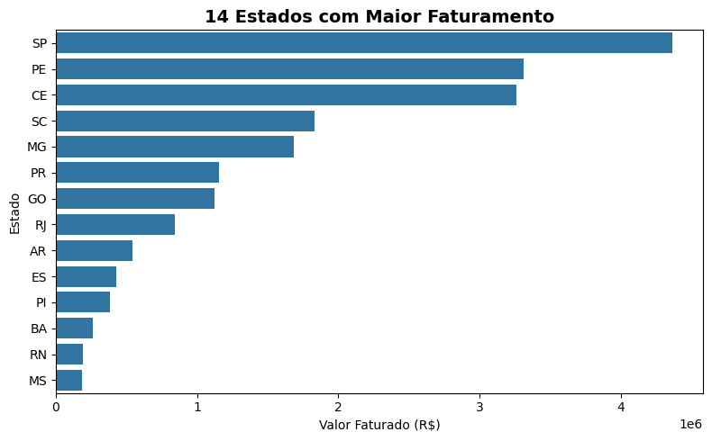

```python
#Agrupar por estado e somar o faturamento
df_estados = df.groupby('estado', as_index=False)['valor_faturado'].sum()

#Ordenar do maior para o menor
df_estados = df_estados.sort_values('valor_faturado', ascending=False)

#Selecionar apenas os 14 estados com maior faturamento para ficar igual ao trabalho da atividade 1
df_estados = df_estados.head(14)

#Criar o gráfico de barras horizontais
plt.figure(figsize=(8,5))
ax = sns.barplot(
    data=df_estados,
    y='estado',
    x='valor_faturado',
)

#Personalizar o gráfico
plt.title('14 Estados com Maior Faturamento', fontsize=14, weight='bold')
plt.xlabel('Valor Faturado (R$)')
plt.ylabel('Estado')
plt.tight_layout()
plt.show()
```

# 2. Clientes que mais fizeram pedidos

```python
#Agrupar por cliente e contar o número de pedidos
df_clientes = df.groupby('cliente', as_index=False)['pedido'].count()

#Renomear a coluna para algo mais intuitivo, assim deixando o grafico melhor.
df_clientes.rename(columns={'pedido': 'quantidade_pedidos'}, inplace=True)

#Ordenar pelos clientes com mais pedidos
df_clientes = df_clientes.sort_values('quantidade_pedidos', ascending=False)

#Criar o Treemap
fig = px.treemap(
    df_clientes.head(10),  #Mostra os 10 principais clientes
    path=['cliente'],
    values='quantidade_pedidos',
    color='quantidade_pedidos',
    title='Clientes que Mais Fizeram Pedidos',
    height=600,
    width=800
)

fig.show()
```

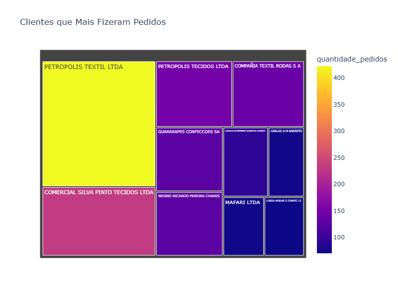

#### !!! Foi necessário colocar o gráfico em png, pois quando o arquivo foi convertido para html, não foi imprimido o gráfico !!!

#### Atenção: foi necessário ajustar largura e comprimento para que o gráfico ficasse igual o da atividade 1. Não está 100% igual, mas o que importa é o aprendizado.

As cores utilizadas são o default da biblioteca.

# 3. Os 10 produtos que mais vendem

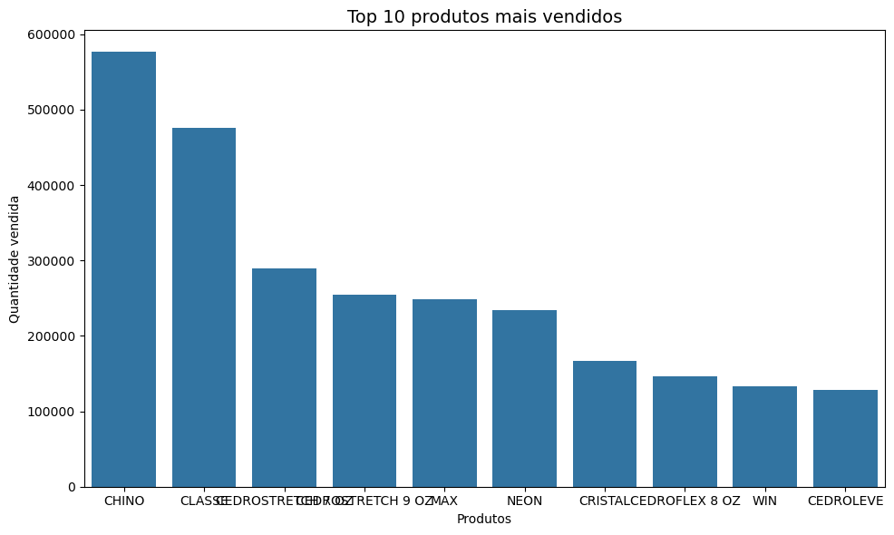

```python
#Agrupar produtos e somar as quantidades
df_produtos = df.groupby('produto', as_index=False)['quantidade_vendida'].sum()

#Selecionar os 10 produtos mais vendidos
top10 = df_produtos.nlargest(10, 'quantidade_vendida')

#Criar gráfico de barras verticais
plt.figure(figsize=(10,6))
sns.barplot(
    data=top10,
    x='produto',
    y='quantidade_vendida',
)

plt.title('Top 10 produtos mais vendidos', fontsize=14)
plt.xlabel('Produtos')
plt.ylabel('Quantidade vendida')
plt.tight_layout()
plt.show()
```

#### Note que os nomes dos produtos se embaralharam.

#### Portanto, na antepenúltima linha do código abaixo, utilizei do rotation para tornar a legenda mais limpa.

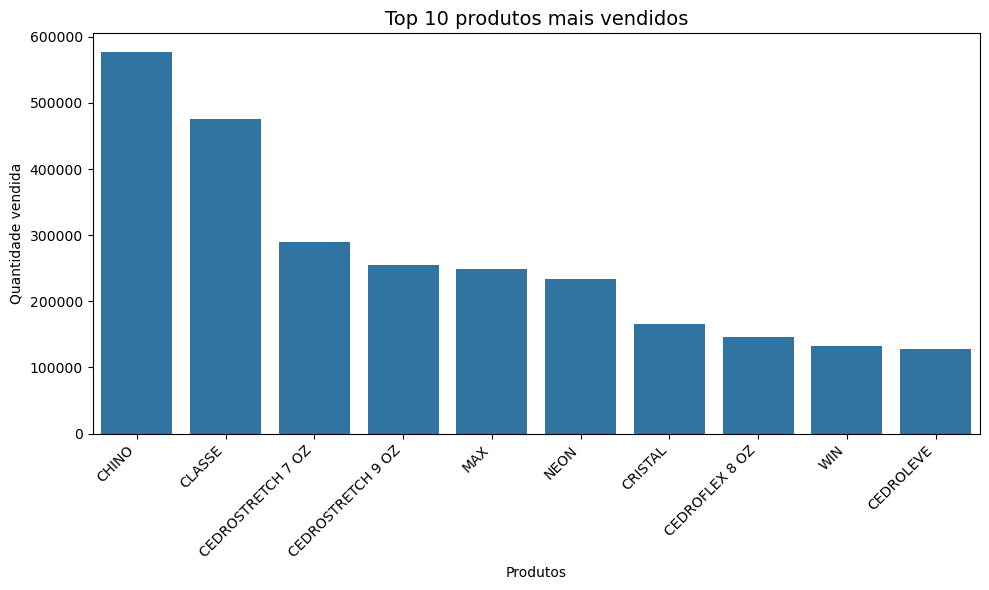

```python
#Agrupar produtos e somar as quantidades
df_produtos = df.groupby('produto', as_index=False)['quantidade_vendida'].sum()

#Selecionar os 10 produtos mais vendidos
top10 = df_produtos.nlargest(10, 'quantidade_vendida')

#Criar gráfico de barras verticais
plt.figure(figsize=(10,6))
sns.barplot(
    data=top10,
    x='produto',
    y='quantidade_vendida',
)

plt.title('Top 10 produtos mais vendidos', fontsize=14)
plt.xlabel('Produtos')
plt.ylabel('Quantidade vendida')
plt.xticks(rotation=45, ha='right')
plt.tight_layout()
plt.show()
```

# Conclusão

As análises realizadas demonstram a importância de utilizar ferramentas de dados para compreender melhor o desempenho comercial da empresa. Por meio dos gráficos e indicadores, é possível identificar clientes estratégicos, produtos mais vendidos e regiões com maior faturamento. Essas informações são essenciais para apoiar a tomada de decisões, otimizar a produção e direcionar ações comerciais de forma mais eficiente.